# Family complexity-287g Visuals

FE

May 23, 2018

# Family complexity models - PUMA population data

Below, I present model predictions from a series of models of family complexity outcomes as a function of 287g participation. Outcomes include:

- ckhhsize
- ckhhfams
- cpgkid
- cpklivesmom
- cpknolivespar
- cpklivessinmom
- cpklivessinpar
- cpknparhead
- cpknfamhead
- cpmixgen

I describe the model specification at the beginning of each section. Outcome variables are labeled on the y axis of all plots.

The models take the form:

$$\textrm{E}(\sqrt{outcome_{it}}) \sim \alpha_i + \delta_j + \sum_{t=j}^{g}\theta_{j}X_{ij} + \varepsilon_{ij}$$

Alpha is a vector of county fixed effects, delta is a vector of event-relative time fixed effects (with non-implementing counties set to constant j= -1, j=0 is impementation year), X_ij is the interaction between ever-active and event-time.

# ALL CASES, NO TRENDS

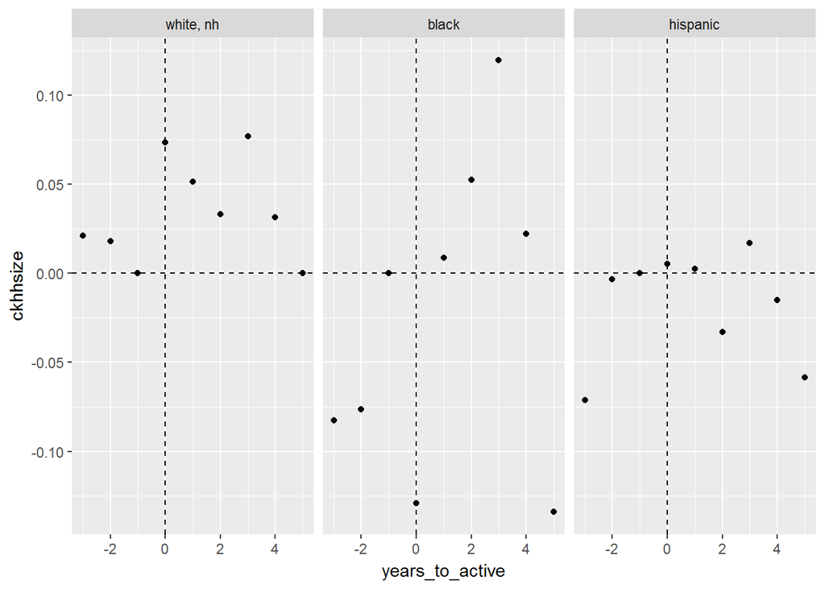

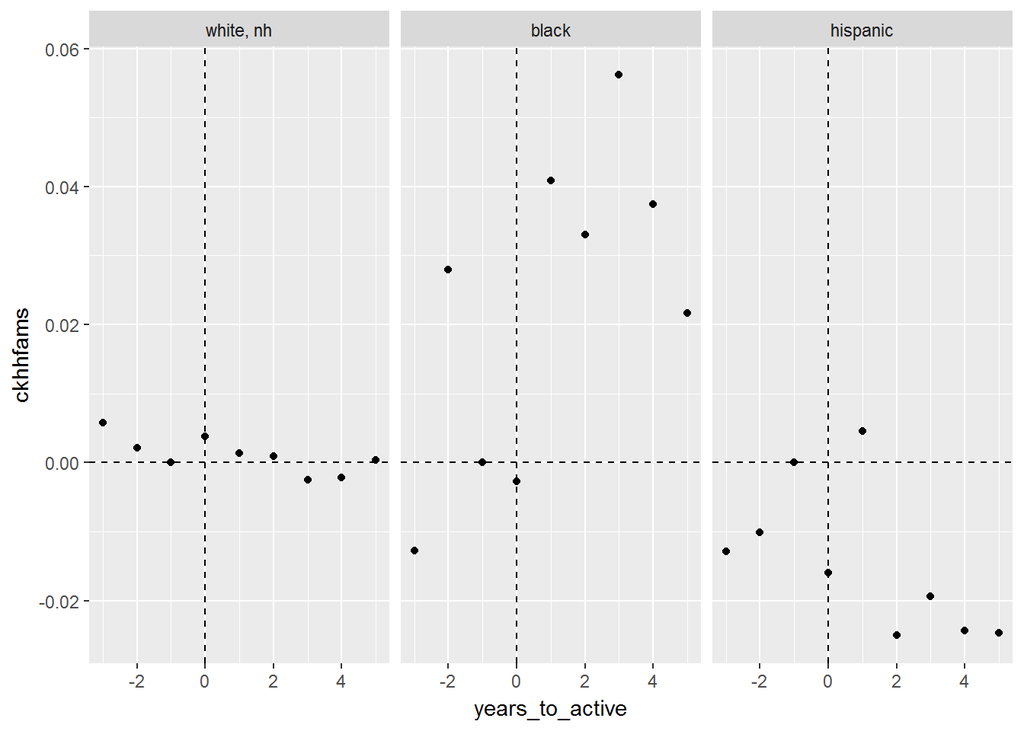

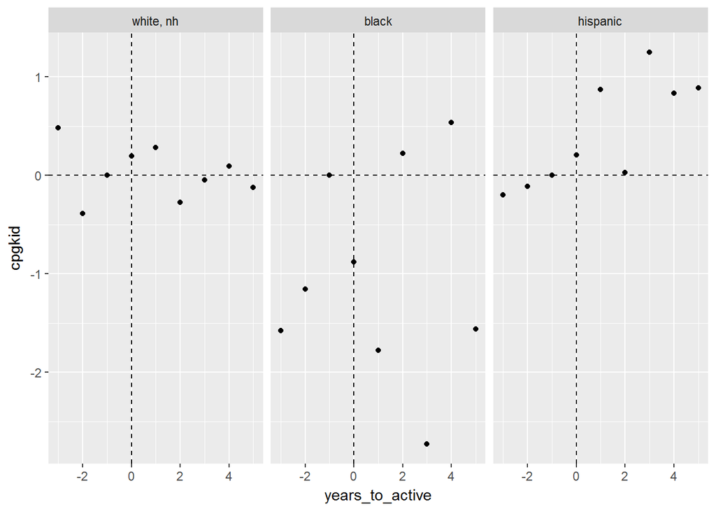

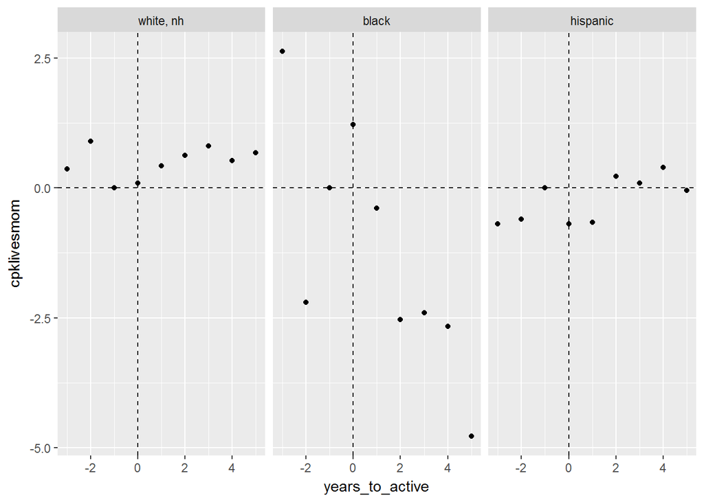

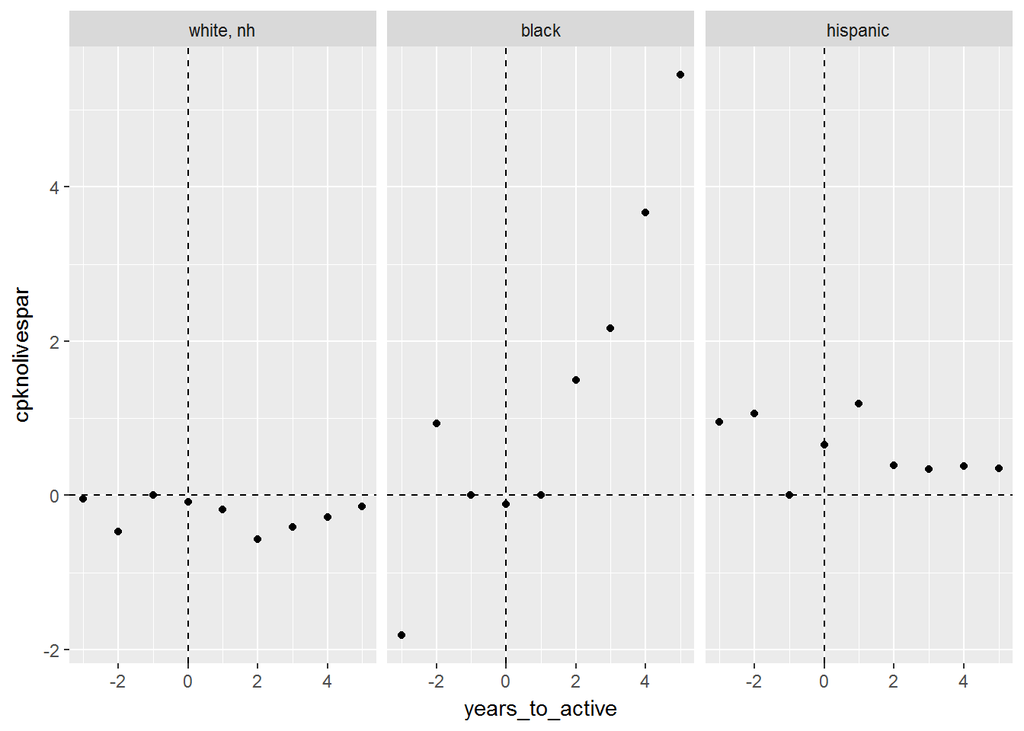

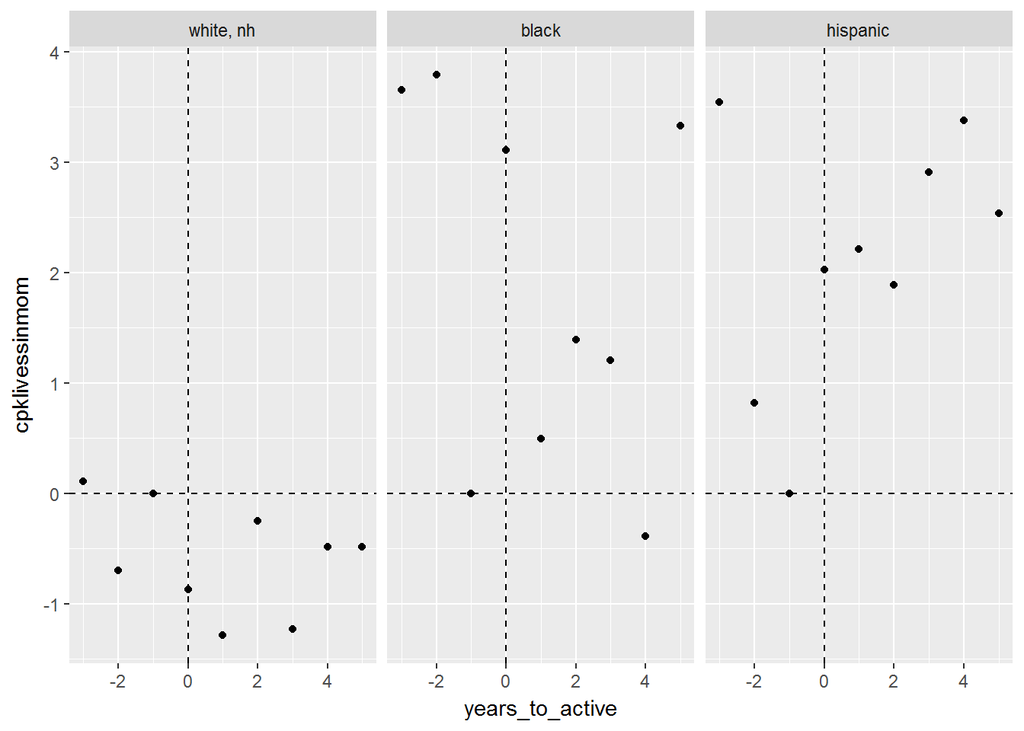

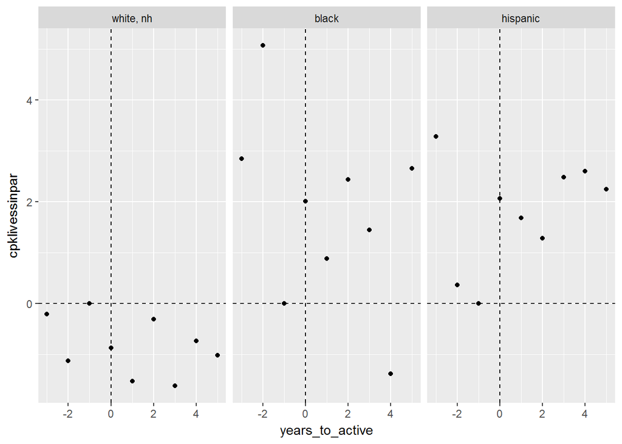

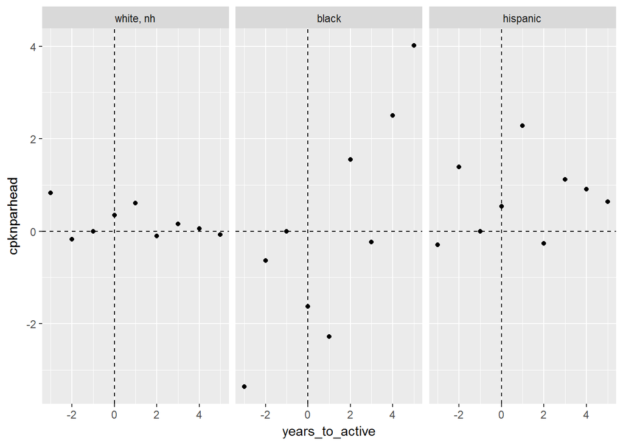

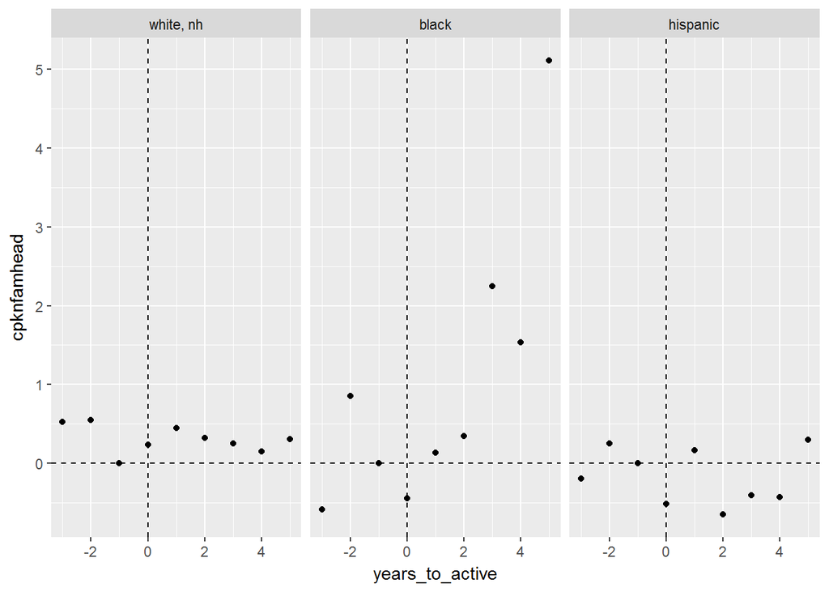

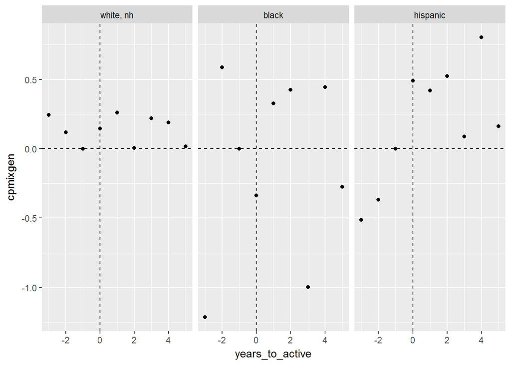

# WITH COUNTY TRENDS, ALL CASES

These models add a county*year trend to the models

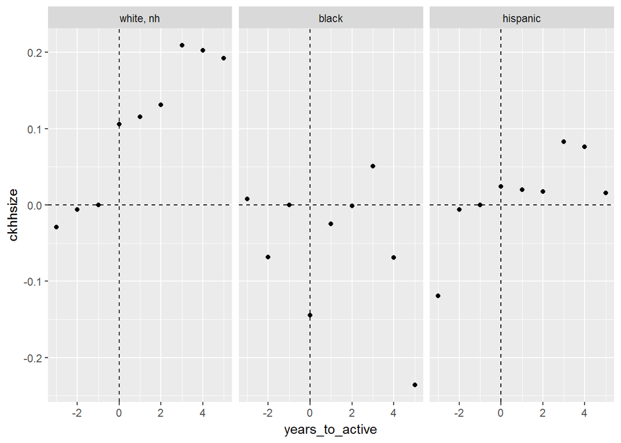

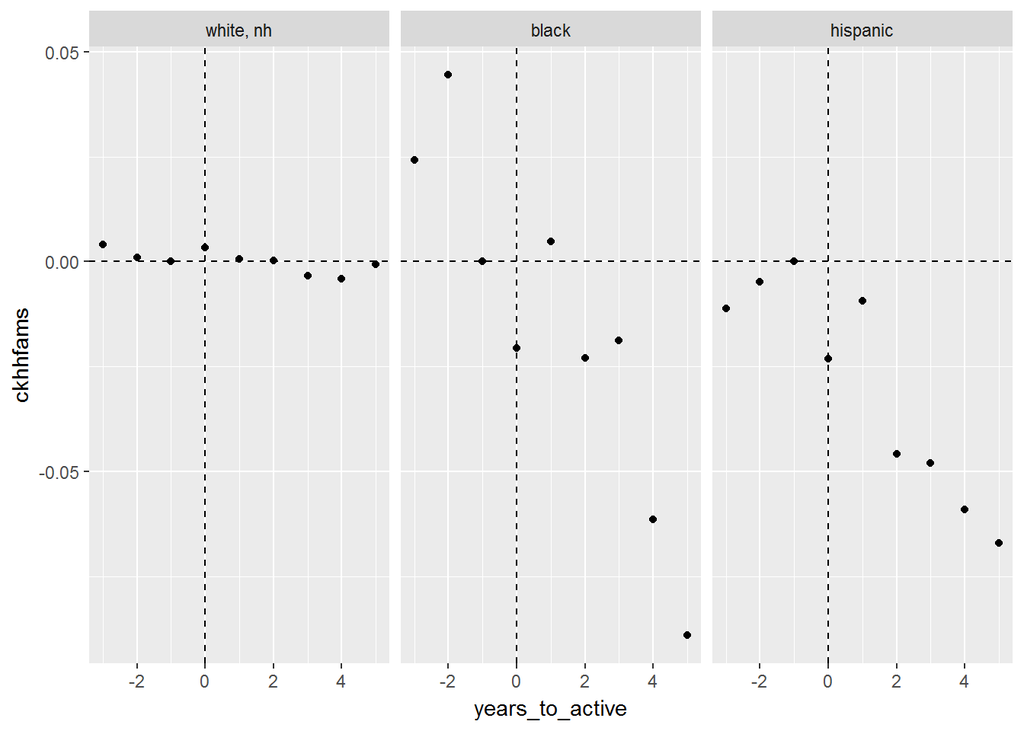

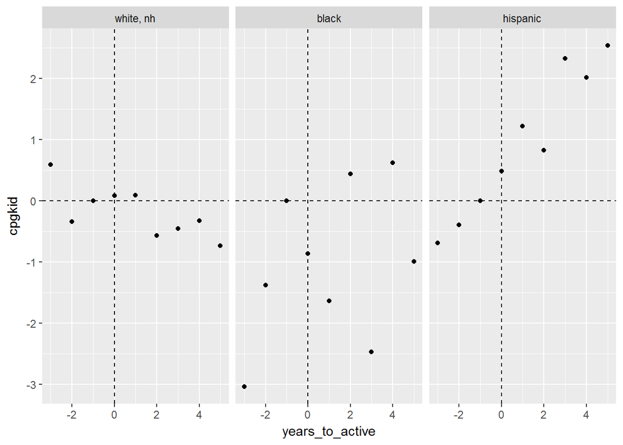

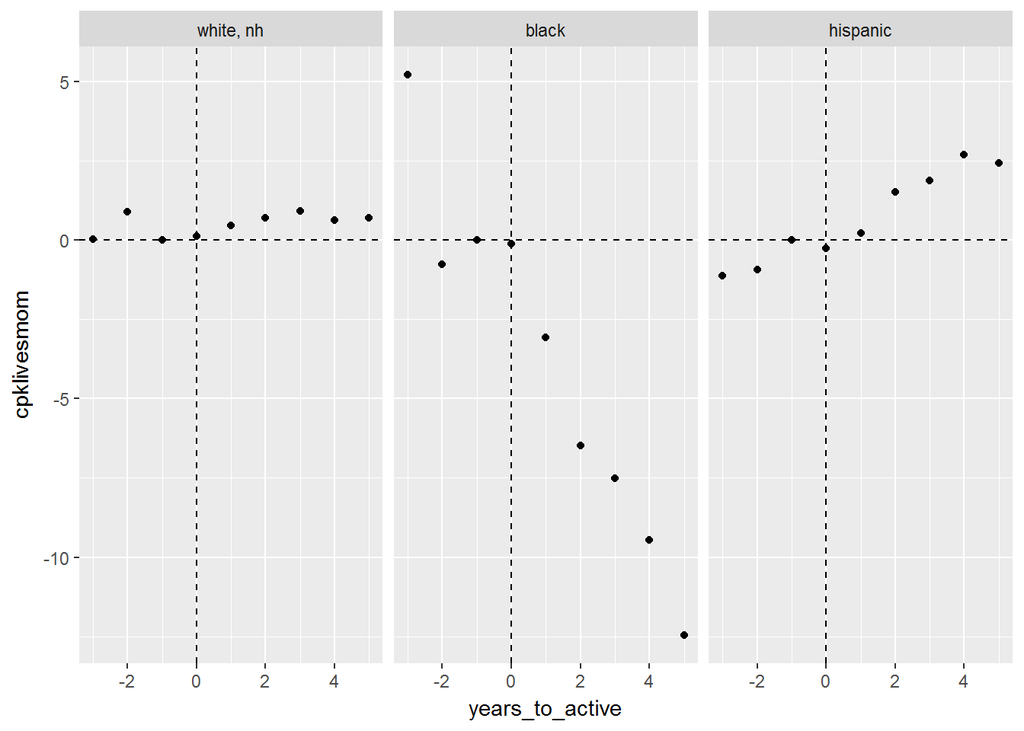

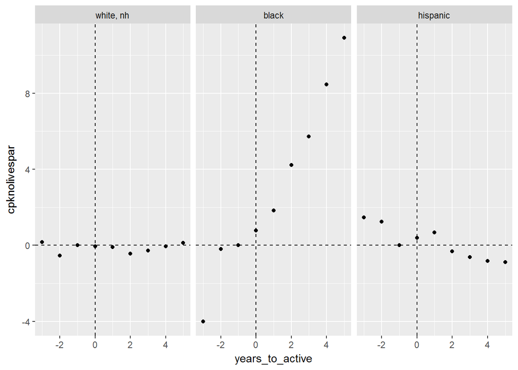

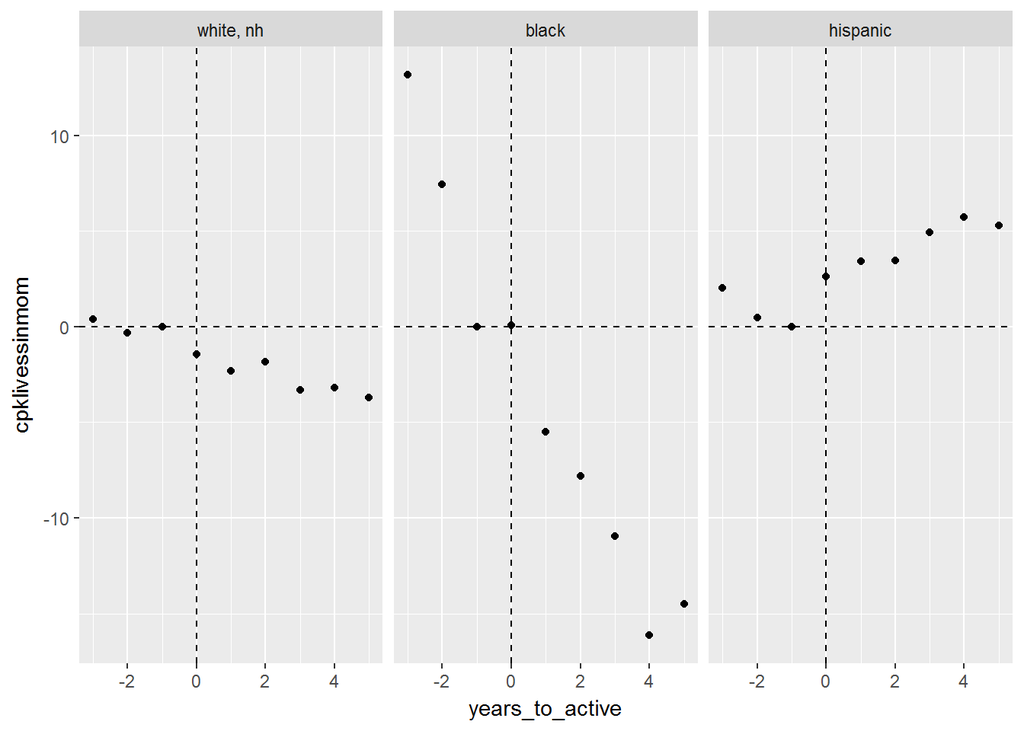

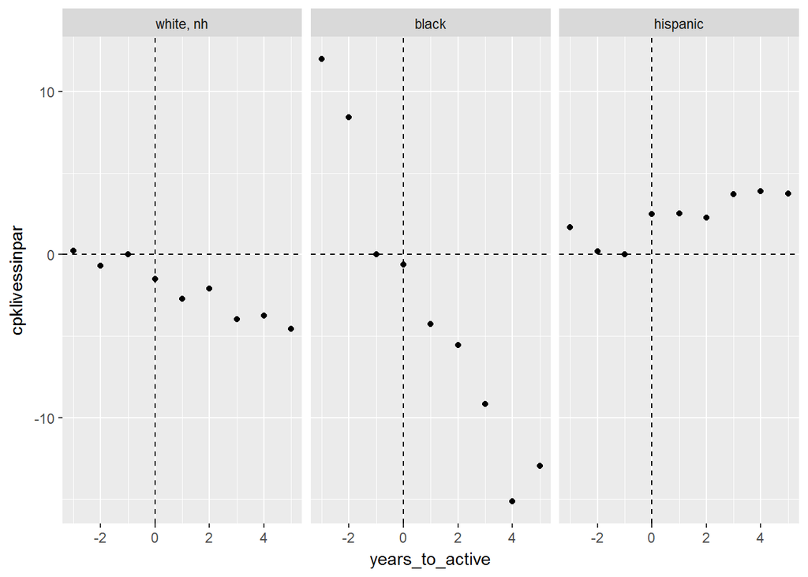

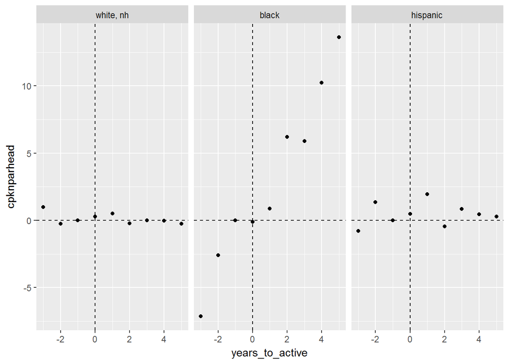

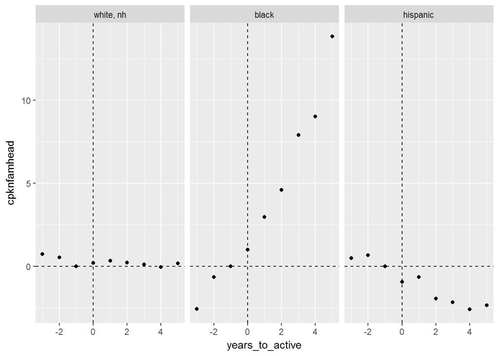

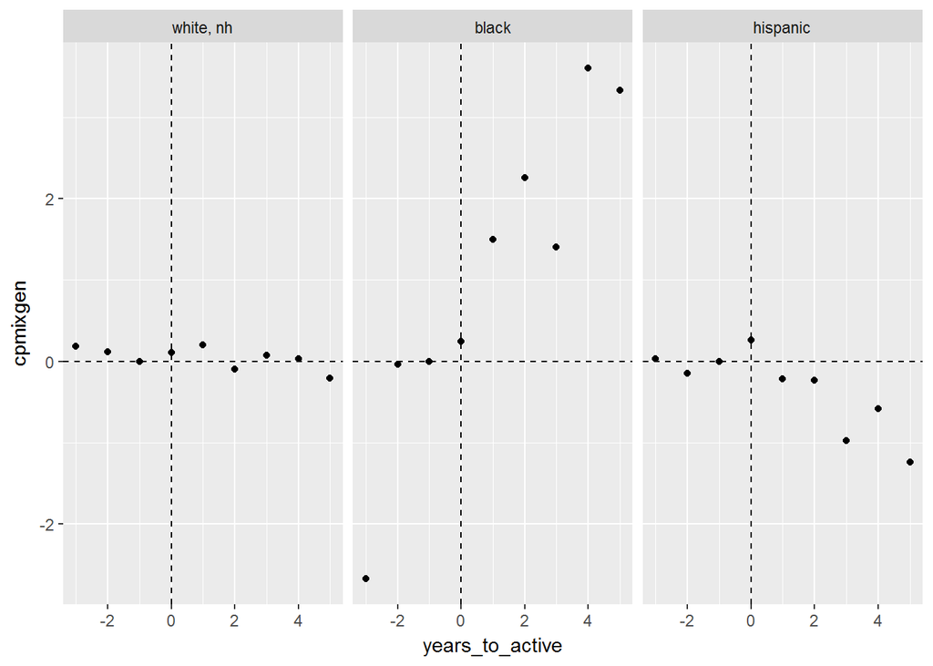